# HSI_Unet_model_3_r2

##### Predicting patchs using Best unet_m2 weights

```python
unet_m2.load_weights('/content/model_2_save2/unet_m2_best_model_e50+49.h5')
```

```python
!wget --header="Host: doc-10-3o-docs.googleusercontent.com" --header="User-Agent: Mozilla/5.0 (Windows NT 10.0; Win64; x64) AppleWebKit/537.36 (KHTML, like Gecko) Chrome/98.0.4758.102 Safari/537.36" --header="Accept: text/html,application/xhtml+xml,application/xml;q=0.9,image/avif,image/webp,image/apng,*/*;q=0.8,application/signed-exchange;v=b3;q=0.9" --header="Accept-Language: en-US,en;q=0.9" --header="Cookie: AUTH_82jcsesreiehjbhkrct3c4mrj1raokod_nonce=nbiprhol3touc" --header="Connection: keep-alive" "https://doc-10-3o-docs.googleusercontent.com/docs/securesc/rg90kivf62vcrm9d2s7vb24hsj0c3fo2/h9jlc8qjfic9o71tc7l53b16fbb7pg9h/1646372025000/16522560826923149764/00176583124175523585/1JZ8M4EiQvHAyugt3qa3xUse9_XdTdID5?e=download&ax=ACxEAsZ834z3IKgN4qDHUGebvZYBUb1__I2LZwwkqLujCJJgKvztbdoDoU32BSrjLOmWGXFYGOKgdluvsEfV8XthBCHztL7P3kBAnS4v9yNgdWmmjVMP4KgQhVrI9NQmPKLZZh7K2SLIni12NEz_RSsjWTP9VoqNt0pmZAr9c_zwt9oeWPuoLf78j-vWBJMK3E0CNM8E3MPnu7nrAWQ3B3mb2a6HOzD6V97YFwSY_j7E5jpikSaQwtAnv1B4rpnGOwErtcWvJ5Z5Mad1MeV3yxdst7vqK7tz5oL1OB7qSf9Bd9gx7mCuzBB-tXSHrZ7eHOkvUyTydqC-JKYz_QzZ6zTSEfXm4YJNZiMmmTBCn2wg5cssMmuc-YtRt-UvLnS3vzlKt6pxDx0vi3Aizql9HcV59Ni4Bll_ToXa2zG4iQSlvwXCTktRd8kEFoYQfWnqyAipresTepnwev9ImIpmlvqvyjc6A5jtiwjul6mfJiDffLjst53xEgGfVlmIQ3v1iAdfV-oa_un7JytYjqWaDx0hnsk1BHzT0s5aGKofiBjoP6aHS-EfV51dI9I41Tgm4WrJIe3RCksNQEzdghzHb7-o3Huyx83-KqSfkLICjsQSLxHJoqxWmMRf9wW9Kwrkyt_HDXD1KSCm3J364EzY7dXEENN0W4NUj3R-DVK_fURH&authuser=0&nonce=nbiprhol3touc&user=00176583124175523585&hash=9af4sf51kra0lbh2lktlff0oae5n2neq" -c -O 'unet_m2_best_model_e50+49.h5'
```

```
--2022-03-04 05:34:54--  https://doc-10-3o-docs.googleusercontent.com/docs/securesc/rg90kivf62vcrm9d2s7vb24hsj0c3fo2/h9jlc8qjfic9o71tc7l53b16fbb7pg9h/1646372025000/16522560826923149764/00176583124175523585/1JZ8M4EiQvHAyugt3qa3xUse9_XdTdID5?e=download&ax=ACxEAsZ834z3IKgN4qDHUGebvZYBUb1__I2LZwwkqLujCJ…
Resolving doc-10-3o-docs.googleusercontent.com (doc-10-3o-docs.googleusercontent.com)... 142.251.6.132, 2607:f8b0:4001:c5a::84
Connecting to doc-10-3o-docs.googleusercontent.com (doc-10-3o-docs.googleusercontent.com)|142.251.6.132|:443... connected.
HTTP request sent, awaiting response... 200 OK
Length: 28038648 (27M) [application/octet-stream]
Saving to: ‘unet_m2_best_model_e50+49.h5’

unet_m2_best_model_ 100%[===================>]  26.74M  52.2MB/s    in 0.5s

2022-03-04 05:34:55 (52.2 MB/s) - ‘unet_m2_best_model_e50+49.h5’ saved [28038648/28038648]
```

```python
# Loading saved model weights
unet_m2.load_weights('unet_m2_best_model_e50+49.h5')
```

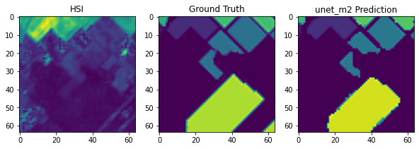

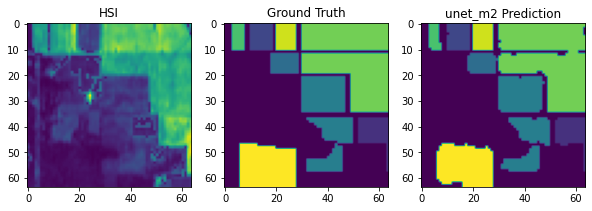

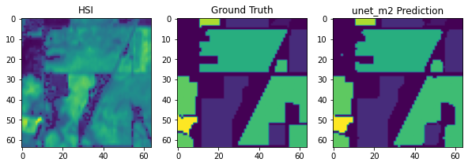

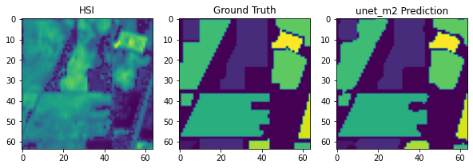

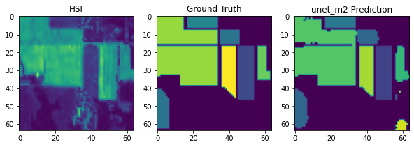

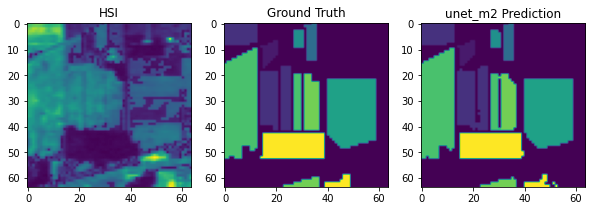

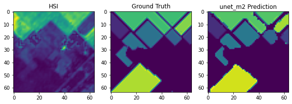

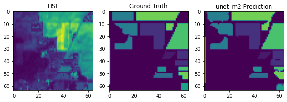

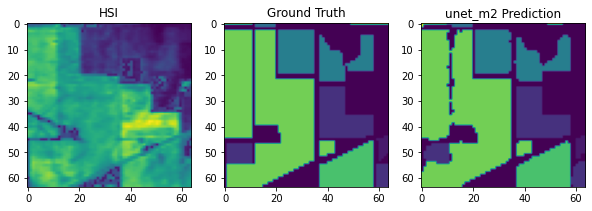

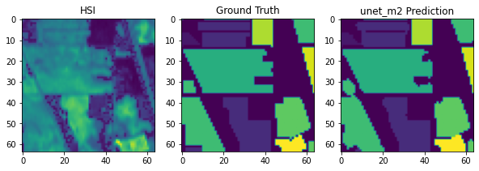

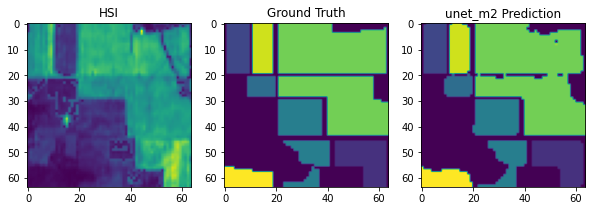

```python
# Plotting Model prediction of segmentation alongside HSI and Ground Truth
i=0
for im, gt in zip(X_test[20:100],y_test[20:100]):

    # model prediction
    pred = unet_m2.predict(im[np.newaxis,:,:,:])

    # generating the image based on the max probability of particular class
    prediction = np.argmax(pred,axis=-1)

    # plotting HSI image vs ground truth vs prediction
    plt.figure(figsize=(10,6))
    plt.subplot(131)
    plt.imshow(im[:,:,20])
    plt.title('HSI')
    plt.subplot(132)
    plt.imshow(gt)
    plt.title('Ground Truth')
    plt.subplot(133)
    plt.imshow(prediction[0])
    plt.title('unet_m2 Prediction')
    plt.colorbar(im1,ax=axis[1],shrink=0.4,aspect=16, ticks=range(0,17,1))
    plt.show()
    i+=1
    if(i>10):
        break
```

##### unet_m2 prediction for complete image

Generating the segmentation of original image (145x145) from patches

```python
HSI_orig_patch = img_patch_list_new[0]
HSI_orig_patch.shape
```

```
(10, 10, 64, 64, 95)
```

```python
# Loading data associated with the original image (145x145)
HSI_orig_dataset = []
for i in range(HSI_orig_patch.shape[0]):
  for j in range(HSI_orig_patch.shape[1]):
    single_patch = HSI_orig_patch[i][j]
    single_patch = Std_scaler.transform(single_patch.reshape(-1,single_patch.shape[-1])).reshape(single_patch.shape)
    HSI_orig_dataset.append(single_patch)
```

```python
# Converting original patch list to numpy array
HSI_orig_dataset = np.array(HSI_orig_dataset)
```

```python
HSI_orig_dataset.shape
```

```
(100, 64, 64, 95)
```

```python
# predicting for individual patch
pred  = unet_m2.predict(HSI_orig_dataset)
prediction = np.argmax(pred,axis=-1)
```

```python
pred.shape
```

```
(100, 64, 64, 17)
```

```python
# individual patch is combined to form a grid of patches
grid = 0
img_pred = np.zeros((10, 10, 64, 64))
for i in range(10):
  for j in range(10):
    img_pred[i][j] = prediction[grid]
    grid+=1
```

###### Unpatchified prediction

```python
# converting the predicted patches into complete image using unpatchify
HSI_orig_pred = patch.unpatchify(img_pred, (145,145))
```

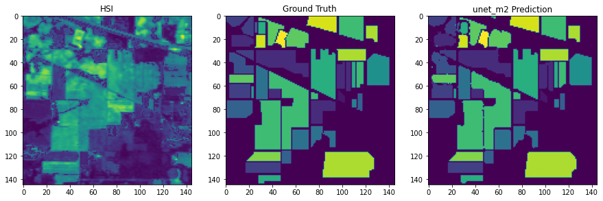

```python
# plottng comparison of HSI vs Ground truth vs unet_m2 predictions
plt.figure(figsize=(15,15))
plt.subplot(131)
plt.imshow(img[:,:,30])
plt.title('HSI')
plt.subplot(132)
plt.imshow(img_gt)
plt.title('Ground Truth')
plt.subplot(133)
plt.imshow(HSI_orig_pred)
plt.title('unet_m2 Prediction')
plt.show()
```

Note: In unpatchify method, each patch at the overlapping regions are replaced by next patch. Alternative approach for stitching all patches is presented below.

###### Prediction based on max score of patches

This is done to consider max probability from multiple prediction for the overlapping regions. In this way the best class is selected at overlapping regions by using argmax along third axis and modulo operator for 17

```python
# Generating the 3D probabilities grid of all patches associated with full image.
grid = 0
grp = 0
img_prediction = np.zeros((145, 145, 100*17))
for i in range(10):
  for j in range(10):
    img_prediction[i*9:i*9+64,
                   j*9:j*9+64,
                   grp:grp+17] = pred[grid]
    grid+=1
    grp+=17
```

```python
# Identifying the classes of each pixel from probabilities values of all patches corresponding to image(145x145)
prediction = np.argmax(img_prediction,axis=-1)%17
```

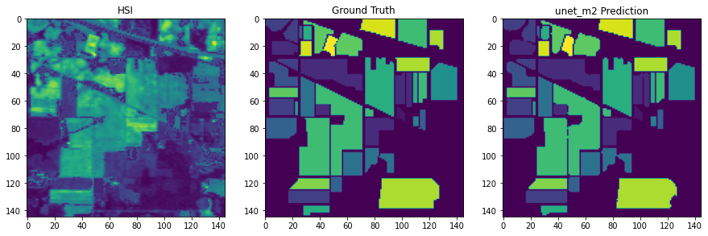

```python
# Plotting the segmentation after identifying the best class for overlapping patches
plt.figure(figsize=(15,15))
plt.subplot(131)
plt.imshow(img[:,:,30])
plt.title('HSI')
plt.subplot(132)
plt.imshow(img_gt)
plt.title('Ground Truth')
plt.subplot(133)
plt.imshow(prediction)
plt.title('unet_m2 Prediction')
plt.show()
```

We can observe that the segmentation is better than the unpatchify generated image. And also better than unet_m1 model

##### Full image prediction score (F1 and kappa)

```python
# Flattening the ground truths and predictions (145x145 image) for score evaluation
y = img_gt.flatten()
y_hat = prediction.flatten()
```

```python
from sklearn.metrics import f1_score, cohen_kappa_score
```

```python
F1_unet_m1 = f1_score(y,y_hat,average='micro')
print('micro F1 score of simple unet model for full image : ',F1_unet_m1)
kappa_unet_m1 = cohen_kappa_score(y,y_hat)
print('kappa score of simple unet model for full image : ',kappa_unet_m1)
```

```
micro F1 score of simple unet model for full image :  0.9925326991676575
kappa score of simple unet model for full image :  0.9894364597996672
```

##### Validation set score

Score evaluation for the test split to understand the performance of predicting the patches

```python
X_test.shape,y_test.shape
```

```
((200, 64, 64, 95), (200, 64, 64))
```

```python
pred_test  = unet_m2.predict(X_test)
prediction_test = np.argmax(pred_test,axis=-1)
```

```python
prediction_test.shape
```

```
(200, 64, 64)
```

```python
y_val = y_test.flatten()
y_hat_val = prediction_test.flatten()
```

```python
F1_unet_m1_val = f1_score(y_val,y_hat_val,average='micro')
print('micro F1 score of simple unet model for validation data: ',F1_unet_m1_val)
kappa_unet_m1_val = cohen_kappa_score(y_val,y_hat_val)
print('kappa score of simple unet model for validation data: ',kappa_unet_m1_val)
```

```
micro F1 score of simple unet model for validation data:  0.95829345703125
kappa score of simple unet model for validation data:  0.9454368938453068
```

```python
# plt.figure(figsize=(15,15))
# im_count=1
# for i in range(10):
#   for j in range(10):
#     plt.subplot(10,10,im_count)
#     plt.imshow(img_pred[i][j])
#     im_count+=1
# plt.show()
```

### Observations:

1. Pretrained U-Net

Model was trained for 50 epochs

- Scores for Full image prediction (Train and test data combined):
  - micro F1 score : 86.6%
  - kappa score : 80.29%
- Scores for test image prediction (only test data/validation data):
  - micro F1 score : 72.68%
  - kappa score : 63.15%
- Though the scores are better for full image, the segmented images are more like globules. This might be due to the model which are trained weights(imagenet) which are trained specifically for RGB images.
1. Simple Unet trained from scratch

Model was trained for 50 epochs and retrained for additional 50 epochs to get better result.

- Scores for Full image prediction (Train and test data combined):
  - micro F1 score : 99.25%
  - kappa score : 98.94%
- Scores for test image prediction (only test data/validation data):
  - micro F1 score : 95.82%
  - kappa score : 94.54%
- This model which is trained from scratch are able to segment the HS image very well. The predicted image are pretty indistinguishable from ground truth. This model can only be used to classify the Hyperspectral Images which have mentioned 16 classes of Indian Pines. Input for the model must be 64x64x95

For Classifying the HS Image of broader classes, Simple U-Net model can be considered and trained from scartch.

These models will be dedicated for Hyper Spectral Image segmentation of specific class set.